# GE_Timeseries analysis

## Summary of the entire data set

```r
summary(Ge_data)
```

```
##        Date           Open             High             Low
##  1/1/2001:   1   Min.   :  16.0   Min.   :  16.4   Min.   :  15.05
##  1/1/2002:   1   1st Qu.: 134.0   1st Qu.: 137.0   1st Qu.: 131.30
##  1/1/2003:   1   Median : 379.0   Median : 385.0   Median : 371.00
##  1/1/2009:   1   Mean   : 377.9   Mean   : 385.3   Mean   : 370.02
##  1/1/2013:   1   3rd Qu.: 581.0   3rd Qu.: 590.0   3rd Qu.: 570.05
##  1/1/2014:   1   Max.   :1099.0   Max.   :1109.0   Max.   :1060.00
##  (Other) :4155
##      Close              WAP          No..of.Shares     No..of.Trades
##  Min.   :  15.75   Min.   :  15.93   Min.   :      1   Min.   :    1
##  1st Qu.: 133.20   1st Qu.: 134.25   1st Qu.:   5168   1st Qu.:  193
##  Median : 377.60   Median : 378.90   Median :  17926   Median :  603
##  Mean   : 376.77   Mean   : 377.94   Mean   :  58095   Mean   : 1294
##  3rd Qu.: 578.45   3rd Qu.: 580.30   3rd Qu.:  53546   3rd Qu.: 1466
##  Max.   :1082.10   Max.   :1091.21   Max.   :3067625   Max.   :77660
##
##  Total.Turnover      Deliverable.Quantity X..Deli..Qty.to.Traded.Qty
##  Min.   :3.300e+01   Min.   :    39       Min.   :  1.57
##  1st Qu.:1.172e+06   1st Qu.:  3037       1st Qu.: 31.64
##  Median :5.143e+06   Median :  9089       Median : 45.30
##  Mean   :2.220e+07   Mean   : 20997       Mean   : 47.44
##  3rd Qu.:1.782e+07   3rd Qu.: 23440       3rd Qu.: 61.65
##  Max.   :1.993e+09   Max.   :441337       Max.   :100.00
##                      NA's   :444          NA's   :444
##    Spread.H.L       Spread.C.O
##  Min.   :  0.00   Min.   :-88.650
##  1st Qu.:  5.40   1st Qu.: -5.250
##  Median : 12.05   Median : -0.700
##  Mean   : 15.29   Mean   : -1.093
##  3rd Qu.: 20.25   3rd Qu.:  2.500
##  Max.   :250.00   Max.   : 90.950
##
```

```r
str(Ge_data)
```

```
## 'data.frame':    4161 obs. of  13 variables:
##  $ Date                      : Factor w/ 4161 levels "1/1/2001","1/1/2002",..: 3501 3827 3816 3802 3767 3734 3606 3488 3401 3352 ...
##  $ Open                      : num  675 685 704 710 699 ...
##  $ High                      : num  678 695 704 712 710 ...
##  $ Low                       : num  646 670 687 698 691 ...
##  $ Close                     : num  656 676 694 706 709 ...
##  $ WAP                       : num  662 683 696 705 705 ...
##  $ No..of.Shares             : int  2312 2128 479 2521 2537 1804 4491 8257 3870 13180 ...
##  $ No..of.Trades             : int  166 104 43 155 97 77 220 750 220 637 ...
##  $ Total.Turnover            : int  1530677 1452890 333396 1777251 1789108 1270228 3181986 5773259 2756203 9313504 ...
##  $ Deliverable.Quantity      : int  1461 1439 295 1796 2213 1338 3136 4596 2308 7115 ...
##  $ X..Deli..Qty.to.Traded.Qty: num  63.2 67.6 61.6 71.2 87.2 ...
##  $ Spread.H.L                : num  31.5 24.9 17.4 14.1 19 ...
##  $ Spread.C.O                : num  -18.7 -9.05 -9.7 -4 10.2 -0.1 10.6 -11 0.35 30.3 ...
```

### Observation & Analysis

- We observe that there is different opening price for the GE stock at different day.
- R has read the data column either as factor we need convert it to date format

```r
Ge_data$Date=as.Date(Ge_data$Date,format="%Y-%m-%d")
```

### Missing values in time series

- Observe the data to find if any

```r
sum(is.na(Ge_data))
```

```
## [1] 5049
```

```r
colSums(is.na(Ge_data))
```

```
##                       Date                       Open
##                       4161                          0
##                       High                        Low
##                          0                          0
##                      Close                        WAP
##                          0                          0
##              No..of.Shares              No..of.Trades
##                          0                          0
##             Total.Turnover       Deliverable.Quantity
##                          0                        444
## X..Deli..Qty.to.Traded.Qty                 Spread.H.L
##                        444                          0
##                 Spread.C.O
##                          0
```

```r
str(Ge_data$Date)
```

```
##  Date[1:4161], format: NA NA NA NA NA NA NA NA NA NA NA NA NA ...
```

### Creating a data frame for sequence of Days

```r
seq <- data.frame("observedDays"=seq(1,4161))
```

#### Merge the data frames of seq of dates with the dates of stocks obtained from BSE

```r
RtData2=cbind(seq,Ge_data)
head(RtData2)
```

```
##   observedDays Date   Open   High    Low  Close    WAP No..of.Shares
## 1            1 <NA> 674.95 677.85 646.35 656.25 662.06          2312
## 2            2 <NA> 685.10 695.05 670.10 676.05 682.75          2128
## 3            3 <NA> 704.00 704.00 686.60 694.30 696.03           479
## 4            4 <NA> 710.00 712.00 697.95 706.00 704.98          2521
## 5            5 <NA> 699.00 710.00 691.00 709.20 705.21          2537
## 6            6 <NA> 705.15 708.00 697.95 705.05 704.12          1804
##   No..of.Trades Total.Turnover Deliverable.Quantity
## 1           166        1530677                 1461
## 2           104        1452890                 1439
## 3            43         333396                  295
## 4           155        1777251                 1796
## 5            97        1789108                 2213
## 6            77        1270228                 1338
##   X..Deli..Qty.to.Traded.Qty Spread.H.L Spread.C.O
## 1                      63.19      31.50     -18.70
## 2                      67.62      24.95      -9.05
## 3                      61.59      17.40      -9.70
## 4                      71.24      14.05      -4.00
## 5                      87.23      19.00      10.20
## 6                      74.17      10.05      -0.10
```

### Extracting out relative dataSet for further Analysis.

```r
#zoo package
RtData2<- RtData2[,c(1,3)]
head(RtData2)
```

```
##   observedDays   Open
## 1            1 674.95
## 2            2 685.10
## 3            3 704.00
## 4            4 710.00
## 5            5 699.00
## 6            6 705.15
```

### Splitting of the Data

- Random split is not possible because here we will be in need of sequence where by we miss the data points
- splitting is done by sequential splitting

```r
Train=RtData2[10:4161,]
Test=RtData2[1:9,]
```

### converting into time series

- our target variable is opening price

```r
StockSeries <- ts(Train$Open,frequency =5)
```

### Vizualize the time series Data

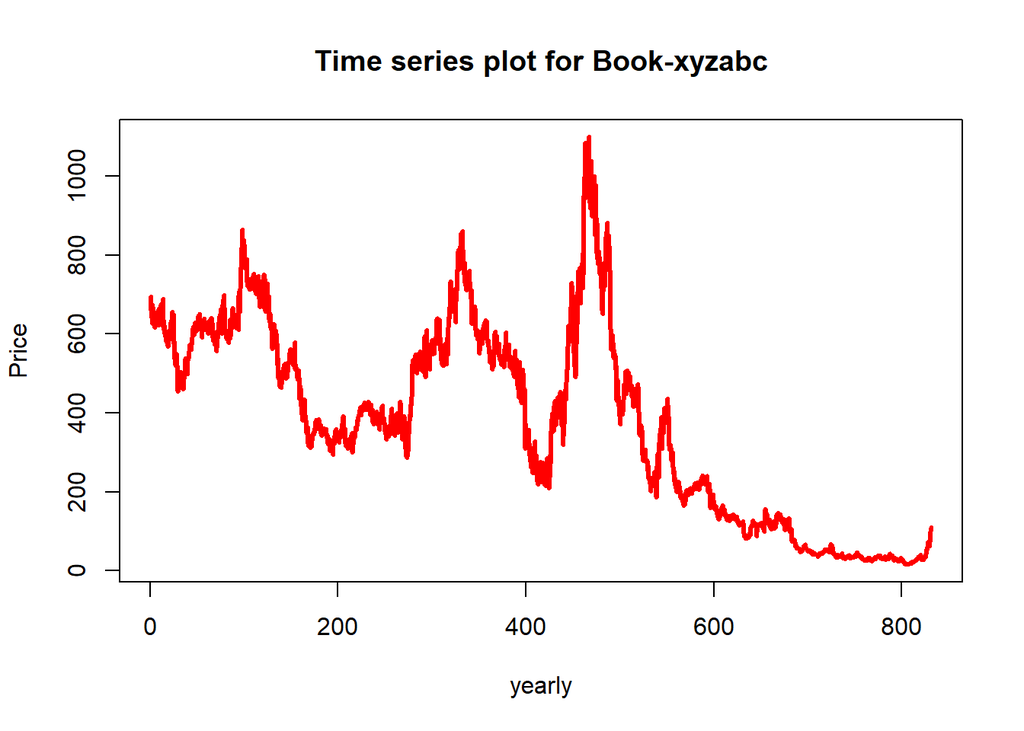

```r
plot(StockSeries,
     type="l",
     lwd=3,
     col="red",
     xlab="yearly",
     ylab="Price",
     main="Time series plot for Book-xyzabc")
```

### Decomposed Time Series * Decompose will provide us with the info on seasonality,trend and randomness

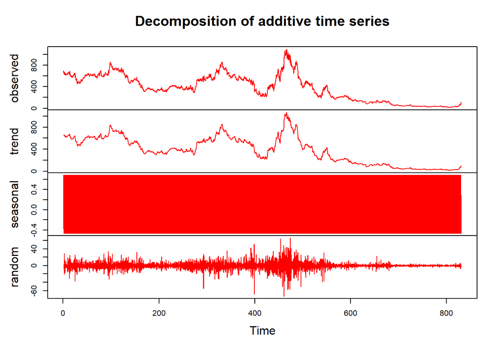

```r
StockSeriesdecomposed=decompose(StockSeries)
plot(StockSeriesdecomposed,col="Red")
```

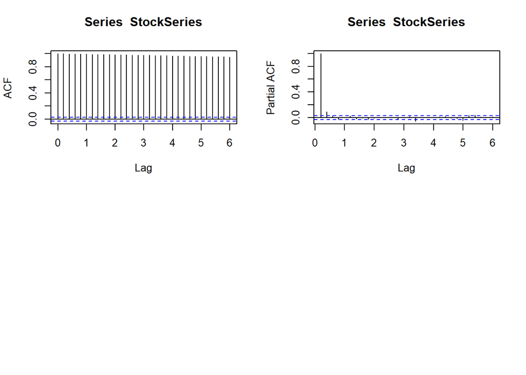

```r
par(mfrow=c(2,2))
acf(StockSeries,lag=30)
pacf(StockSeries,lag=30)
```

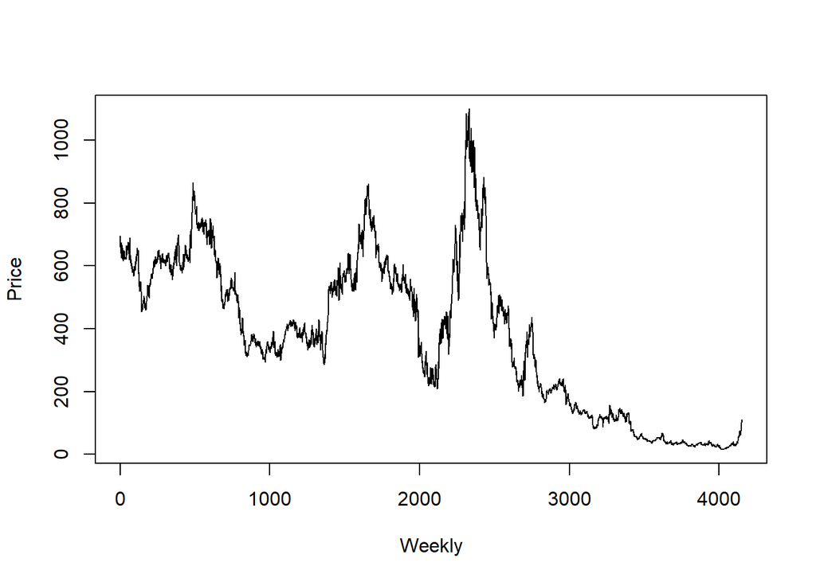

```r
StockSeries1 <- ts(Train$Open, frequency =1)
plot(StockSeries1,xlab = "Weekly",ylab="Price")
```

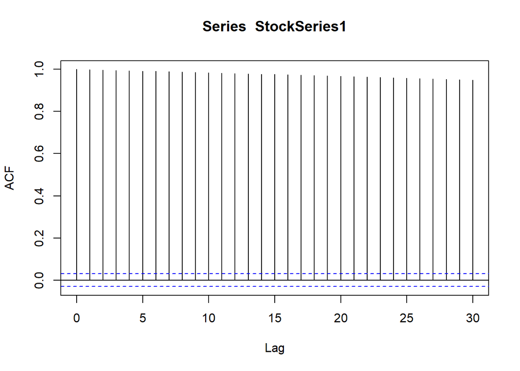

```r
acf(StockSeries1,lag=30)
```

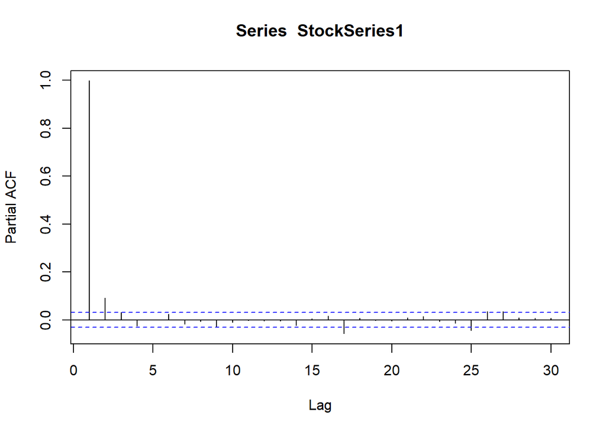

```r
pacf(StockSeries1,lag=30)
```

### Stationarize by differencing

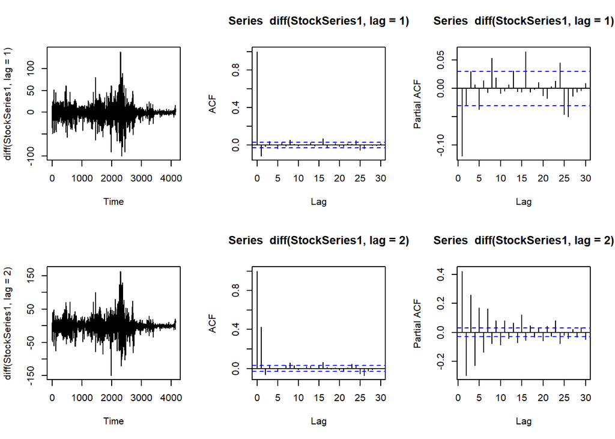

```r
par(mfrow=c(2,3))
plot(diff(StockSeries1,lag = 1),type="l"); acf(diff(StockSeries1,lag = 1),lag=30) ;pacf(diff(StockSeries1,lag = 1),lag=30)
plot(diff(StockSeries1,lag=2),type="l");  acf(diff(StockSeries1,lag = 2),lag=30); pacf(diff(StockSeries1,lag = 2),lag=30)
```

* one lag has stationarize the data we can use ndiffs of forecast package to check no of differences required to stationarize the data

```r
ndiffs(StockSeries1)
```

```
## [1] 1
```

### Modelling the time series using simple moving averages

- Time series Price has trend
- Modelling the time series behaviour by simple moving averages

```r
fitsma <- SMA(StockSeries,n=2)
pred<-forecast(fitsma,h=4)
```

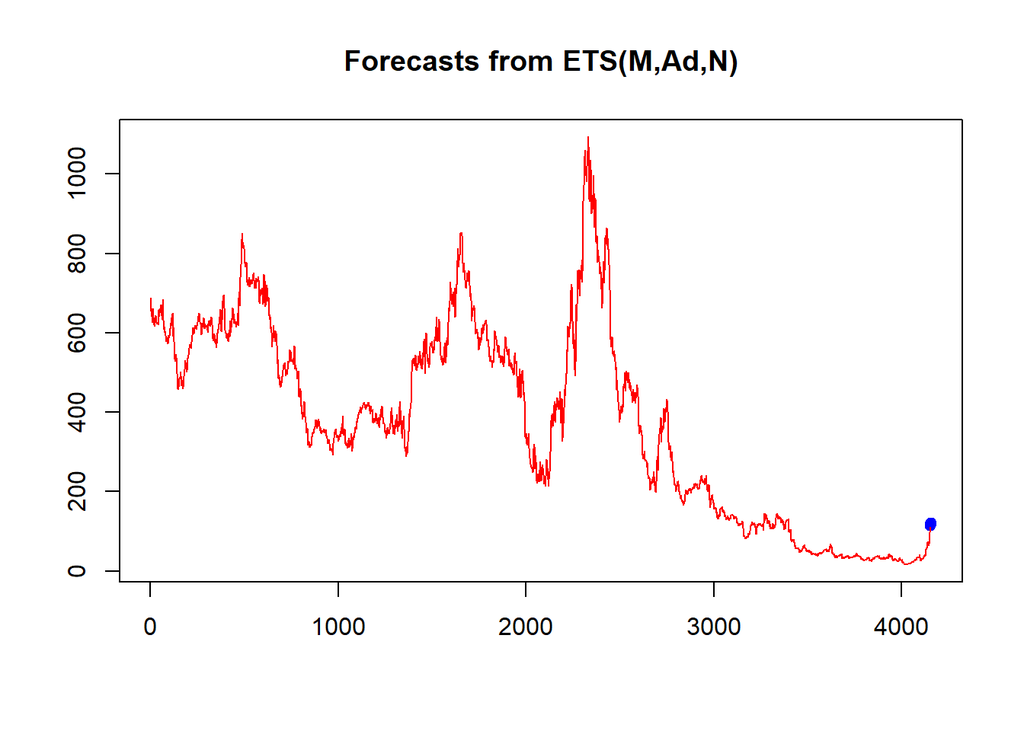

```r
plot(pred)
lines(fitsma,col="red")
```

### Define the metric MAPE

```r
smaMape <- mean(abs((StockSeries[2:length(StockSeries)]-fitsma[2:length(StockSeries)])/StockSeries[2:length(StockSeries)]))
smaMape
```

```
## [1] 0.01316851
```

### Weighted Moving Averages

```r
fitwma<- WMA(StockSeries,n=2,1:2)
wmaMape <- mean(abs((StockSeries[2:length(StockSeries)]-fitwma[2:length(StockSeries)])/StockSeries[2:length(StockSeries)]))
wmaMape
```

```
## [1] 0.008779007
```

```r
pred<-forecast(fitwma,h=4)
```

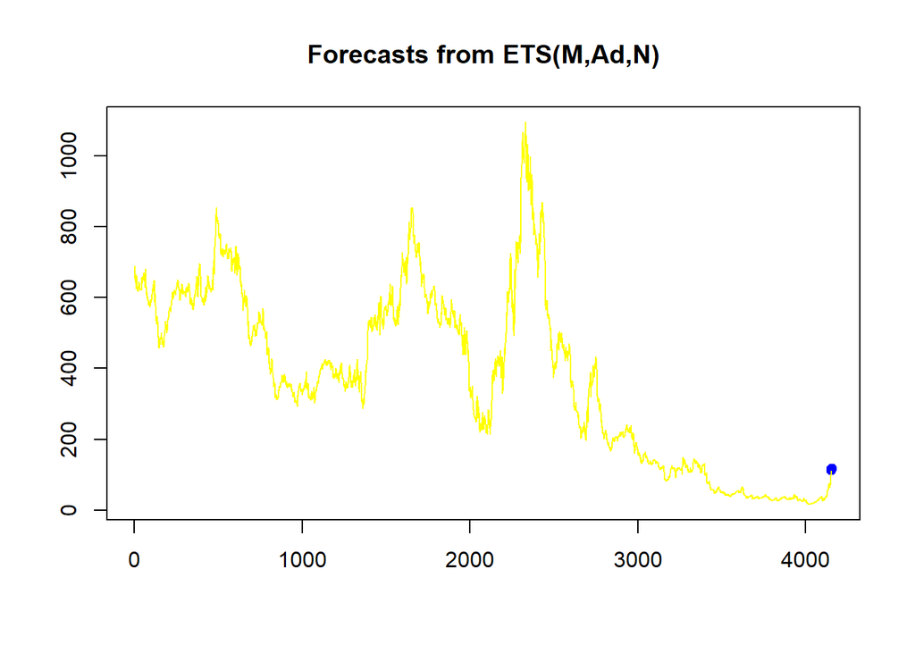

```r
plot(pred)
lines(fitwma,col="yellow")
```

### Exponential Moving Averages

```r
fitEma <- EMA(StockSeries, n = 2)
emaMape <- mean(abs((StockSeries[2:length(StockSeries)]-fitEma[2:length(StockSeries)])/StockSeries[2:length(StockSeries)]))
emaMape
```

```
## [1] 0.009116912
```

```r
pred<-forecast(fitEma,h=4)
```

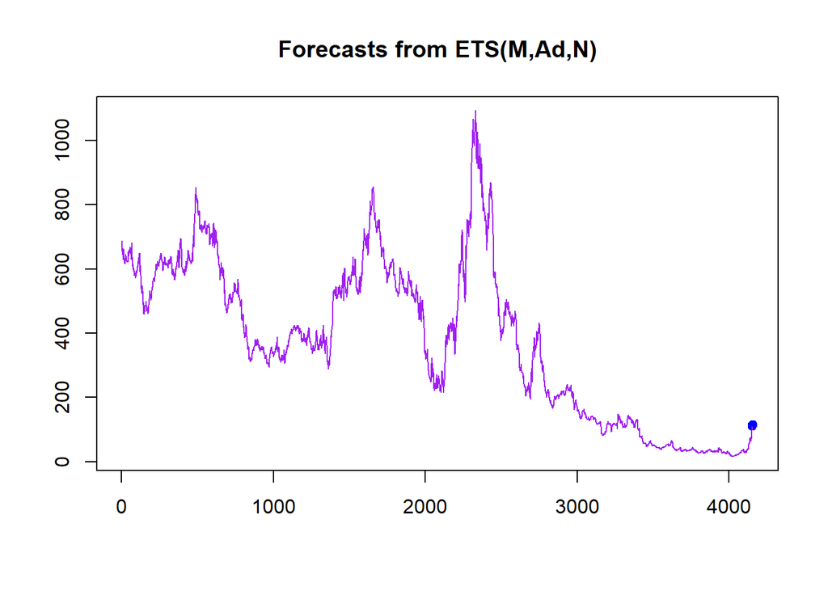

```r
plot(pred)
lines(fitEma,col="purple")
```

## Build a HoltWinters model with trend

```r
holtpriceforecast <- HoltWinters(Train$Open,gamma=FALSE)
head(holtpriceforecast$fitted)
```

```
## Time Series:
## Start = 3
## End = 8
## Frequency = 1
##       xhat    level    trend
## 3 710.0000 695.0000 15.00000
## 4 680.2630 666.2355 14.02747
## 5 668.4209 654.9558 13.46509
## 6 656.5461 643.6319 12.91423
## 7 659.1743 646.4837 12.69062
## 8 663.6563 651.1441 12.51218
```

## HoltWinters model with trend and Seasonality

```r
priceholtforecast <-
HoltWinters(StockSeries, beta=TRUE, gamma=TRUE, seasonal="additive")
head(priceholtforecast$fitted)
```

```
## Time Series:
## Start = c(2, 1)
## End = c(3, 1)
## Frequency = 5
##         xhat    level     trend    season
## 2.0 656.9890 666.3567 -3.905714  -5.46200
## 2.2 662.7920 662.2454 -4.111313   4.65800
## 2.4 667.3802 657.9138 -4.331602  13.79800
## 2.6 644.1048 653.6953 -4.218464  -5.37200
## 2.8 636.9956 649.1564 -4.538854  -7.62200
## 3.0 622.5253 644.4386 -4.717874 -17.19535
```

### Prediction on the Train

```r
holtforecastTrain <- data.frame(priceholtforecast$fitted)
holtforecastTrainpredictions <- holtforecastTrain$xhat
head(holtforecastTrainpredictions)
```

```
## [1] 656.9890 662.7920 667.3802 644.1048 636.9956 622.5253
```

### Prediction on test data

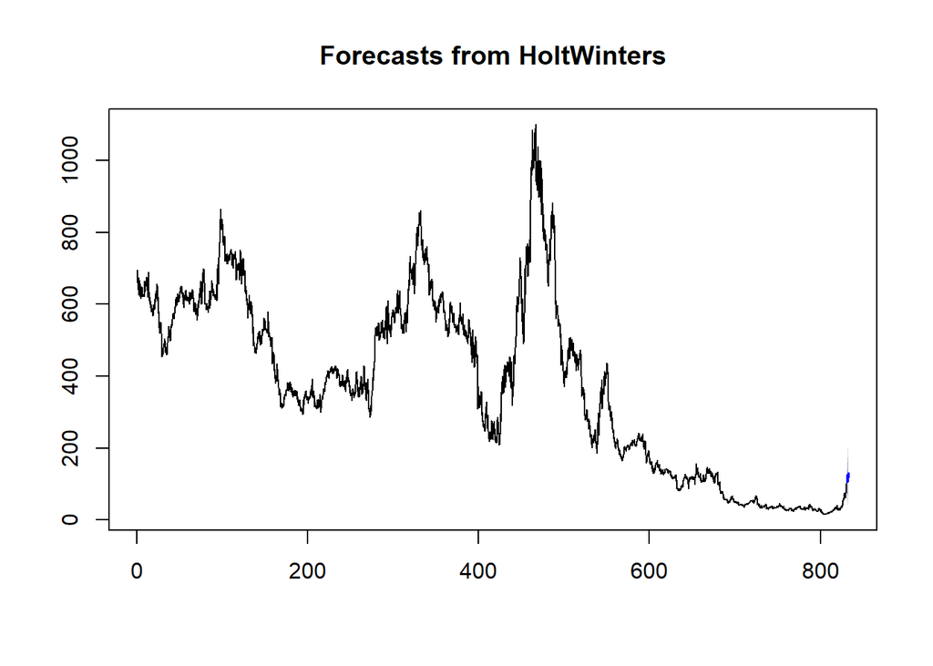

```r
priceforecast<-forecast(priceholtforecast,h = 8)
plot(priceforecast)
```

### Arima Models

```r
model1 <- arima(StockSeries,c(0,0,0))
model1
```

```
##
## Call:
## arima(x = StockSeries, order = c(0, 0, 0))
##
## Coefficients:
##       intercept
##        377.1674
## s.e.     3.8090
##
## sigma^2 estimated as 60241:  log likelihood = -28740.1,  aic = 57484.2
```

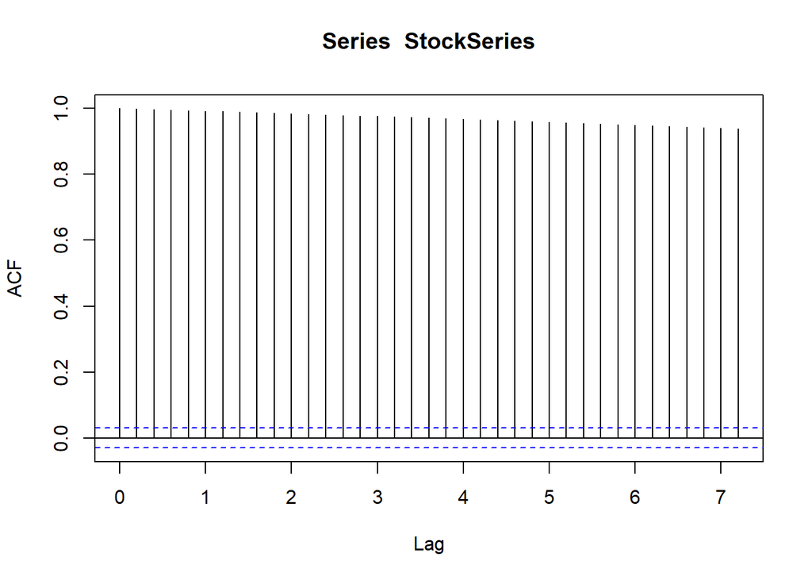

```r
acf(StockSeries)
```

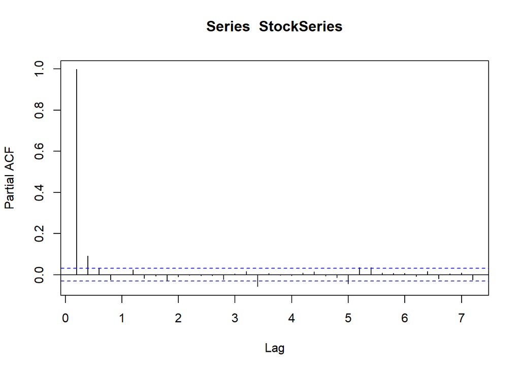

```r
pacf(StockSeries)
```

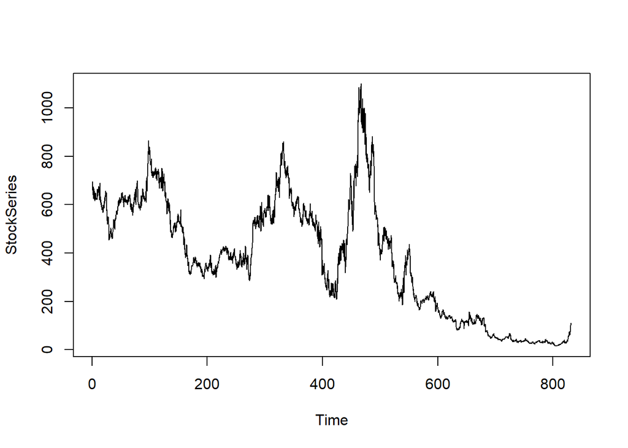

```r
plot(StockSeries)
```

```r
#non seasonal differentiating
ndiffs(StockSeries)
```

```
## [1] 1
```

```r
#seasonal differentiating
nsdiffs(StockSeries)
```

```
## [1] 0
```

## Considering the difference from the graph as d=1 to stationarize

```r
model2 <- arima(StockSeries,c(0,1,0))
model2
```

```
##
## Call:
## arima(x = StockSeries, order = c(0, 1, 0))
##
##
## sigma^2 estimated as 184.3:  log likelihood = -16717.26,  aic = 33436.53
```

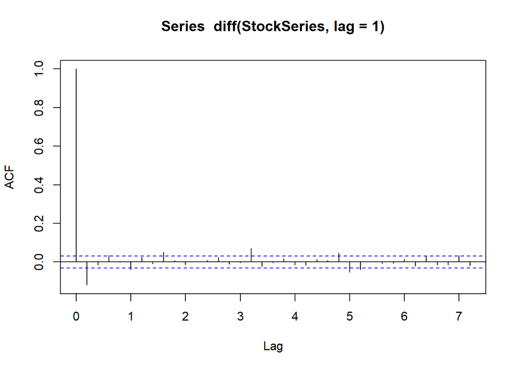

```r
acf(diff(StockSeries,lag = 1))
```

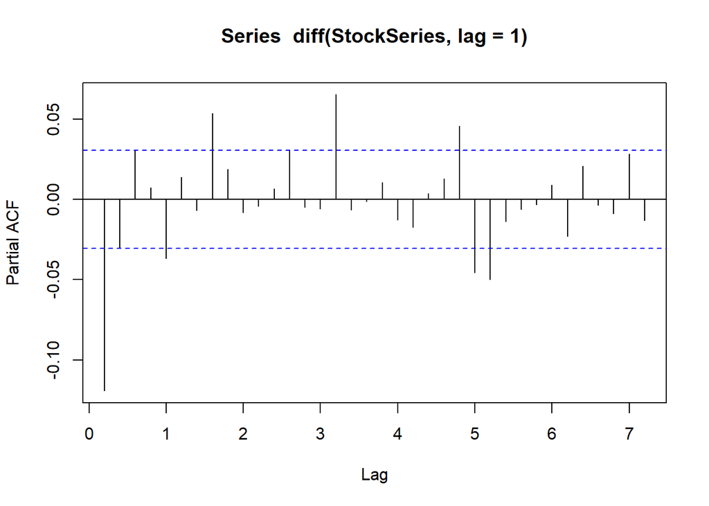

```r
pacf(diff(StockSeries,lag = 1))
```

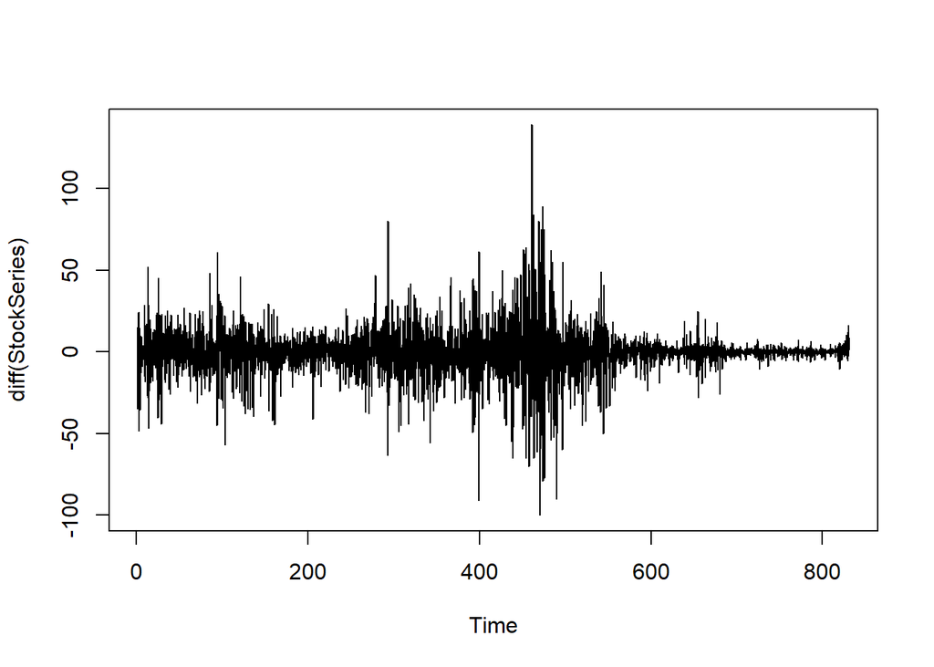

```r
plot(diff(StockSeries))
```

```r
model3 <- arima(StockSeries,c(0,2,0))
model3
```

```
##
## Call:
## arima(x = StockSeries, order = c(0, 2, 0))
##
##
## sigma^2 estimated as 412.6:  log likelihood = -18385.27,  aic = 36772.55
```

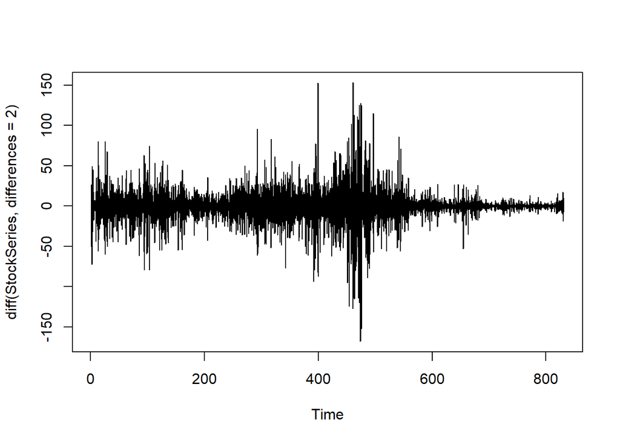

```r
plot(diff(StockSeries,differences = 2))
```

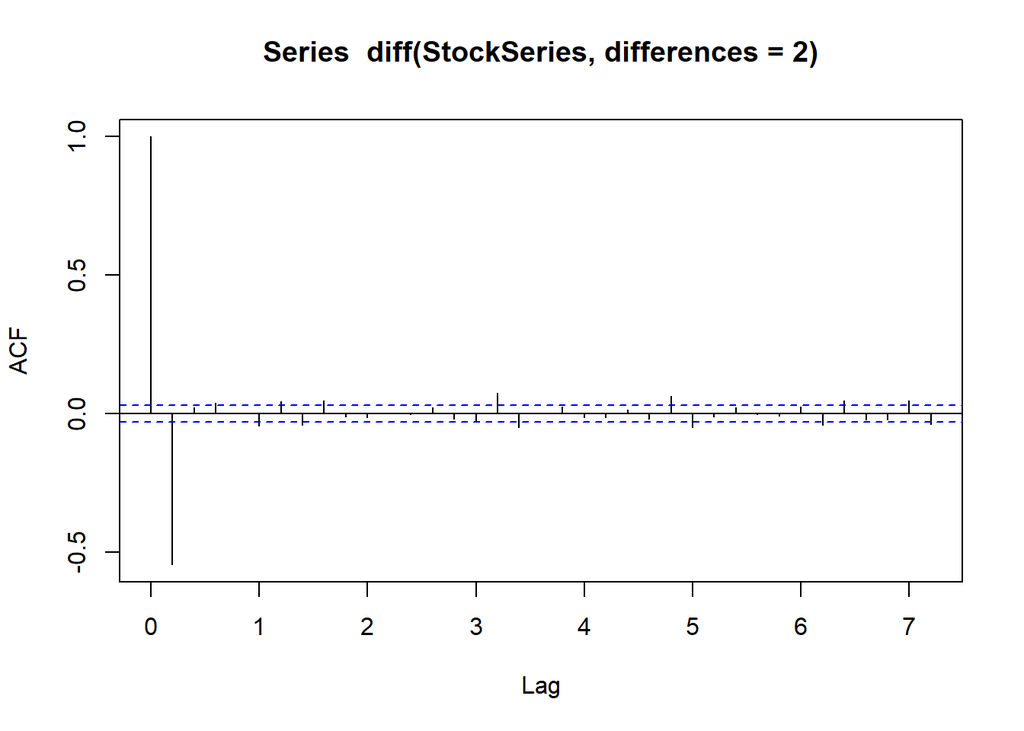

```r
acf(diff(StockSeries,differences = 2))
```

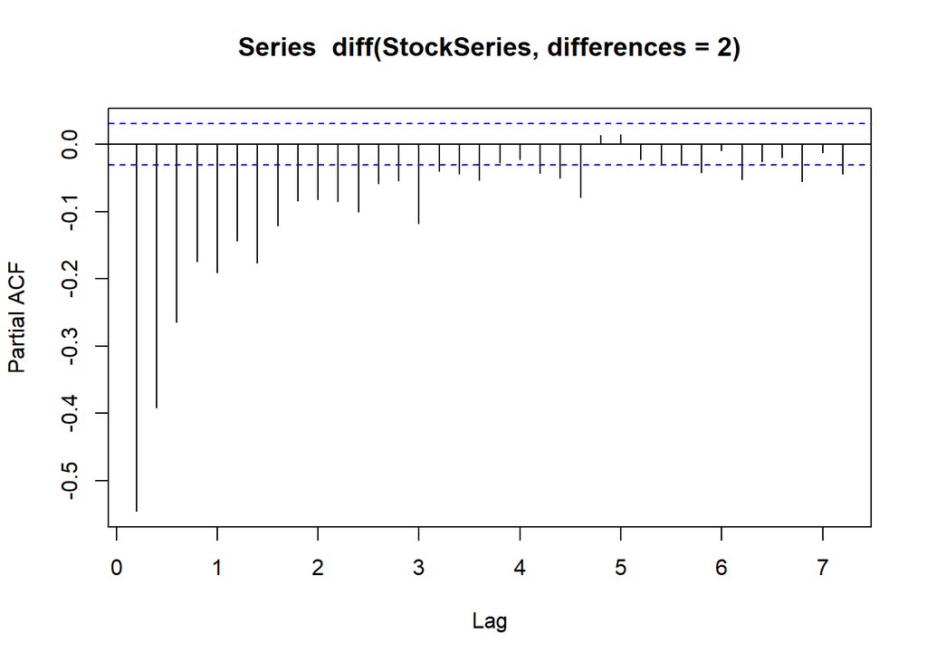

```r
pacf(diff(StockSeries,differences = 2))
```

* Observing the acf and pacf there is significant lag in acf and also in pacf that has to be taken care

```r
model4 <- arima(StockSeries,c(1,1,1))
model4
```

```
##
## Call:
## arima(x = StockSeries, order = c(1, 1, 1))
##
## Coefficients:
##          ar1      ma1
##       0.0385  -0.1609
## s.e.  0.1033   0.1016
##
## sigma^2 estimated as 181.6:  log likelihood = -16686.35,  aic = 33378.69
```

## Plots of the models

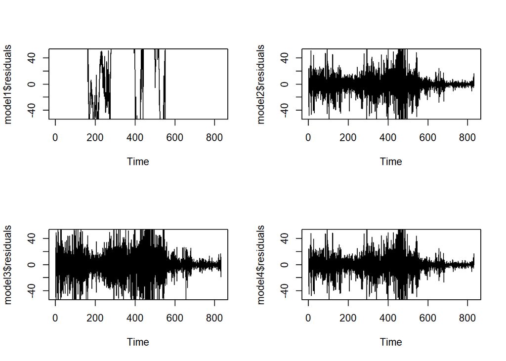

```r
par(mfrow=c(2,2))
plot(model1$residuals,ylim=c(-50,50))
plot(model2$residuals,ylim=c(-50,50))
plot(model3$residuals,ylim=c(-50,50))
plot(model4$residuals,ylim=c(-50,50))
```

### Auto Arima

```r
MODEL_ARIMA <- auto.arima(StockSeries, ic='aic')
summary(MODEL_ARIMA)
```

```
## Series: StockSeries
## ARIMA(2,1,2)(2,0,0)[5]
##
## Coefficients:
##           ar1      ar2     ma1     ma2     sar1     sar2
##       -0.5399  -0.2536  0.4201  0.1772  -0.0368  -0.0125
## s.e.   0.2416   0.1121  0.2436  0.1158   0.0176   0.0156
##
## sigma^2 estimated as 181.4:  log likelihood=-16680.68
## AIC=33375.36   AICc=33375.39   BIC=33419.68
##
## Training set error measures:
##                      ME     RMSE      MAE        MPE    MAPE      MASE
## Training set -0.1618213 13.45581 8.252878 -0.1401859 2.63498 0.4711419
##                      ACF1
## Training set -0.001364712
```

### Forecast on the models

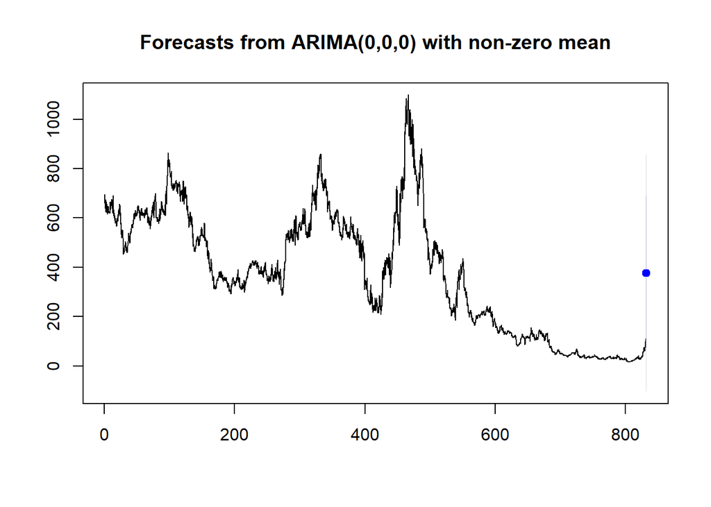

```r
pricearimaforecasts1 <- forecast(model1, h=4)
plot(pricearimaforecasts1)
```

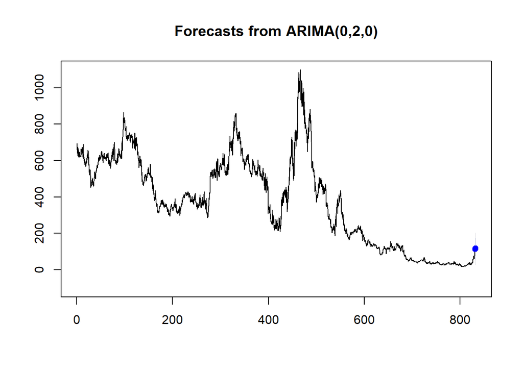

```r
pricearimaforecast3 <- forecast(model3, h=4)
plot(pricearimaforecast3)
```

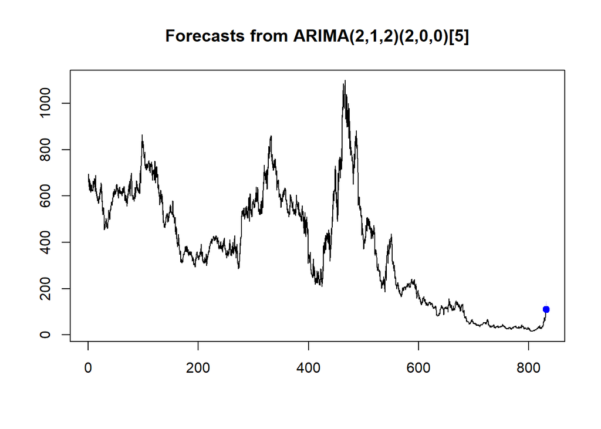

```r
pricearimaforecasts_autArima<- forecast(MODEL_ARIMA,h=4)
plot(pricearimaforecasts_autArima,flwd = 2)
```

```r
summary(MODEL_ARIMA)
```

```
## Series: StockSeries
## ARIMA(2,1,2)(2,0,0)[5]
##
## Coefficients:
##           ar1      ar2     ma1     ma2     sar1     sar2
##       -0.5399  -0.2536  0.4201  0.1772  -0.0368  -0.0125
## s.e.   0.2416   0.1121  0.2436  0.1158   0.0176   0.0156
##
## sigma^2 estimated as 181.4:  log likelihood=-16680.68
## AIC=33375.36   AICc=33375.39   BIC=33419.68
##
## Training set error measures:
##                      ME     RMSE      MAE        MPE    MAPE      MASE
## Training set -0.1618213 13.45581 8.252878 -0.1401859 2.63498 0.4711419
##                      ACF1
## Training set -0.001364712
```

*Comparing the AIC Auto Arima was giving good results for the product item considered